# CSC-496/696: Natural Language Processing and Text as Data

Lecture 10: Neural Networks, Part II

Patrick Wu

Friday, September 27, 2024

## Announcements

- You are allowed a “cheat sheet” for the midterm
- You can handwrite it or type it
- You are allowed one side of a standard $8.5 \times 11$ (letter size) paper
- I will collect the cheat sheets at the end of the exam to verify that content is only written on one side and that it is a letter sized paper

## Announcements

- Assignment 1 solutions and grades will be posted this weekend

## Topics Today

- Neural network training
- Gradient descent
- Backpropagation

## Learning Goals

- Intuitively understanding why we use gradient descent to train neural networks
- Intuitively understanding how backpropagation is used to train a neural network
- Able to count the number of parameters in a fully-connected neural network

## Recap

- We can think of a fully-connected neural network as transforming $p$ input features into $k_1$ features using a weight matrix $\mathbf{W}_1$, and then applying a non-linear function to those resulting features on an elementwise basis
- We can then repeat this for several layers

## Recap

- With the final set of $k_m$ features, we can transform these $k_m$ features into the number of classes we want to estimate
- We can use the softmax function (for multiple classes) or sigmoid function (for a single class) to make a classification

## Recap

- More specifically, this process is called a *forward pass* or *forward propagation*
- We move input data through the network layers to produce an output

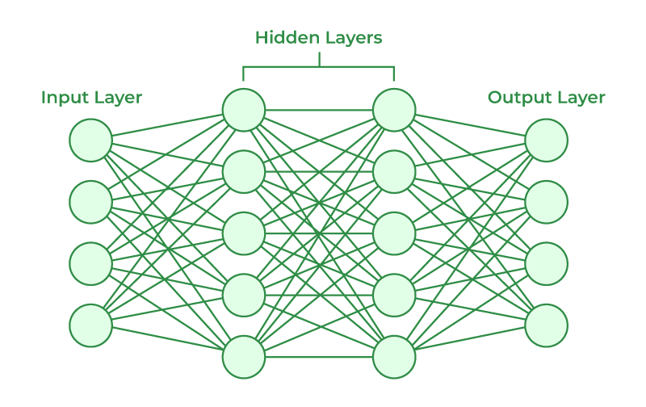

So what we need to know we can use the training data with labels to adjust the weights and biases of this neural network

We’ll then show it new data and see how well this network does

What we need is a way to “tell” the model how good or bad its prediction is

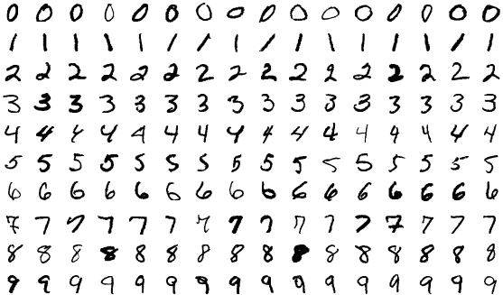

- We’ll do this using a *loss function*
- Loss function: used to measure how well or poorly a model is making predictions
  - The model makes a guess (prediction)
  - The loss function compares the guess to the correct answer (the actual data)
  - It then calculates the number that represents how “off” the answer was, which is the **loss**
- The goal in training a model is to *minimize this loss*

*Linear Regression*

$$\text{RSS} = \sum_{i=1}^{n} (y_i - \widehat{y}_i)^2$$

*Naive Bayes*

$$L = -\sum_{i=1}^{n} \log P(y_i | \mathbf{x})$$

*Logistic Regression*

$$L(\beta) = -\sum_{i=1}^{n} \left( y_i \log(\widehat{y}_i) + (1-y_i)\log(1 - \widehat{y}_i) \right)$$
where $\widehat{y}_i$ is the predicted probability that sample $i$ belongs to class 1

*Fully-Connected Neural Network (Classification, Binary)*

$$L(\mathbf{W}) = -\frac{1}{n}\sum_{i=1}^{n} \left( y_i \log(\widehat{y}_i) + (1-y_i)\log(1 - \widehat{y}_i) \right)$$

This is called a *binary cross entropy loss function*

What about the case where there’s multiple classes (like with the MNIST data)?

## Recap: Softmax Function

For a vector $\mathbf{z}$ with $k$ dimensions, the *softmax* is defined as

$$\text{softmax}(z_i) = \frac{\exp(z_i)}{\sum_{j=1}^{k} \exp(z_j)}$$

It is another squishification function that **acts on a vector**

- All elements of $\mathbf{z}$ are now between 0 and 1
- The sum of all elements of $\text{softmax}(\mathbf{z})$ is 1

$$L(\mathbf{W}) = -\frac{1}{n} \sum_{i=1}^{n} \sum_{k=1}^{K} y_{i,k} \log\left( \widehat{y}_{i,k} \right)$$

- $n$: number of samples
- $K$: number of classes
- $y_{i,k}$: true label indicator where $y_{i,k} = 1$ if sample $i$ belongs to class $k$ and $y_{i,k} = 0$ otherwise
- $\widehat{y}_{i,k}$: predicted probability that sample $i$ belongs to class $k$

$$\widehat{y}_{i,k} = \text{softmax}(\mathbf{z}_i)_k = \frac{\exp(z_{i,k})}{\sum_{j=1}^{K} \exp(z_{i,j})}$$
where $z_{i,k}$ is the $k$th output of the last layer, and $\mathbf{z}_i$ is the vector of outputs of the last layer with a total of $K$ elements

- Recall that $\log(1) = 0$
- That means that if $\widehat{y}_{i,k} \to y_{i,k} = 1$, then the loss decreases
- If there is a discrepancy between $\widehat{y}_{i,k}$ and $y_{i,k}$, then the loss increases

At the observation level:

- use loss function to calculate how good (or lousy) the network is at predicting that input

At the training set level

- average the losses across all observations to get an average measure of how good (or lousy) the network is at its prediction task
- What we aim to do is to *minimize* the loss function
- This is a widely studied problem in mathematical optimization
- Optimization: selection of a “best” element with regard to
  - some kind of criteria
  - some set of available alternatives
- As we discussed last class, the functional form of neural networks is highly non-convex, meaning that it has a lot of valleys and peaks.
- Let’s look at a polynomial that is non-convex with local and global minima: $f(x) = x^6 - 3x^4 + 2x^2$

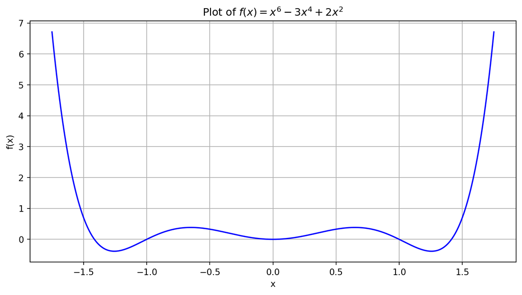

Let’s use a *gradient descent* approach: let’s take the derivative at a specific point.

- If the slope is *positive*, we’ll move left
- If the slope is *negative*, we’ll move right

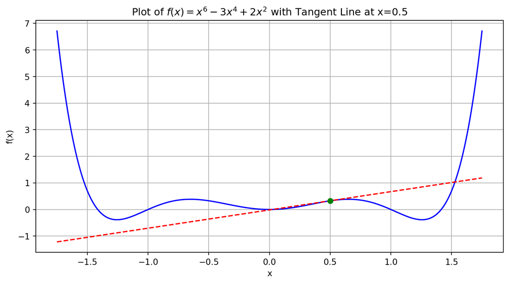

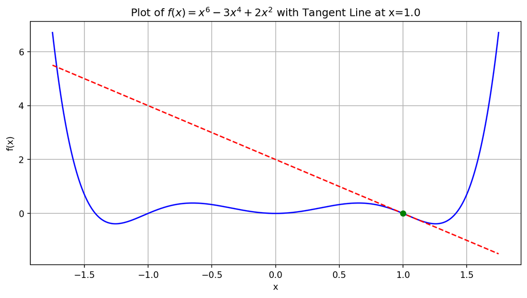

We can iteratively find a local minimum by using the following update rule:

$$x_{\text{new}} = x_{\text{current}} - \eta f'(x_{\text{current}})$$

where $\eta$ is the *learning rate*

- Gradient: a **vector** that represents the direction and rate of the steepest increase of a function
- In one dimension, the gradient is just the derivative
  - $f'(x) > 0$: the function is increasing at $x$
  - $f'(x) < 0$: the function is decreasing at $x$
  - $f'(x) = 0$: could be maximum, minimum, or an inflection point
- In two dimensions, the gradient is:

$$\nabla f(x_1, x_2) = \begin{bmatrix} \frac{\partial f}{\partial x_1} & \frac{\partial f}{\partial x_2} \end{bmatrix}$$

In general, for a function $f(x_1, x_2, \dots, x_n)$,

$$\nabla f(x_1, x_2, \dots, x_n) = \begin{bmatrix} \frac{\partial f}{\partial x_1} & \frac{\partial f}{\partial x_2} & \dots & \frac{\partial f}{\partial x_n} \end{bmatrix}$$

Gradients have **direction** and **magnitude** (that’s why they’re vectors!!)

Because gradients tell us the direction and rate of steepest **ascent**, we just go the opposite way

That’s why for a one-dimensional function, the gradient descent algorithm is

$$x_{\text{new}} = x_{\text{current}} - \eta f'(x_{\text{current}})$$

We multiply the derivative by $\eta$ to ensure that the update is small and controlled, rather than potentially overshooting the minimum

$\to$ This is a hyperparameter set by the engineer of the neural network

- This generalizes to the loss function for a neural network
- We’re going to use gradient descent to update the parameters of our neural network by using small nudges
- These small nudges are going to be guided by the gradient: which nudges yield the biggest decrease in the loss function
- In other words, the gradient gives us a formal way to describe which weights and biases need to change the most to yield the fastest decrease in the loss function

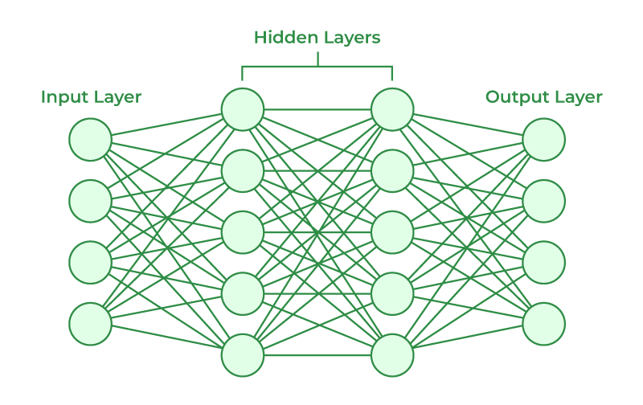

We can count the number of parameters here: $4 \times 5 + 5 \times 5 + 5 \times 4 = 65$. Then we also have the biases: $5 + 5 + 4 = 14$. So in total, there are $79$ parameters in this neural network.

- We’ll initialize the network with random numbers, and of course, this model will not do well
- We’ll then adjust these numbers with small nudges using the gradient descent approach
- Gradient descent will be guided by the loss function — the goal is to find a local minimum of the loss function

## Parameter Counting

- Counting the number of parameters in a neural network gives us an idea of why modern neural networks, such as GPT, contain *billions* of parameters
- Let’s take the MNIST numbers example: recall that we flatten a $28 \times 28$ image into a single vector, so each image is a $784$-dimensional vector
- Let’s say that we use two hidden layers, each with 128 hidden states. So that means we’re going to transform:
  - 784 features to 128 features
  - 128 features to 128 features
  - 128 features to 10 features (the 10 possible answers)

Then, the number of parameters in this model is:

$$(784 \times 128) + (128 \times 128) + (128 \times 10) = 118,016$$

Don’t forget the bias parameters as well: $128 + 128 + 10 = 266$

So in total, there are $118,282$ parameters

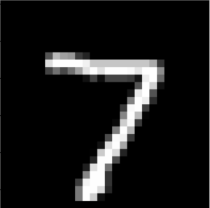

Let’s say that we use a really simple neural network: 2 hidden layers with 4 hidden states each. And let’s say that we only want the network to predict whether this image depicts a 7 or not (a binary classification problem)

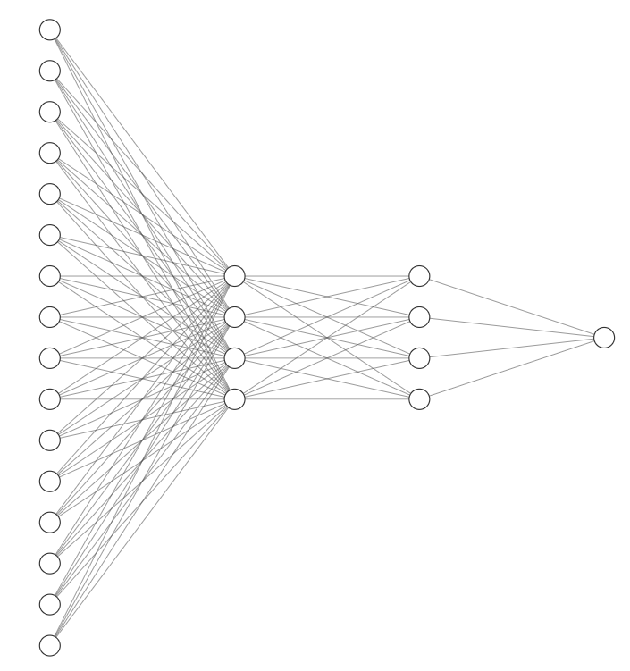

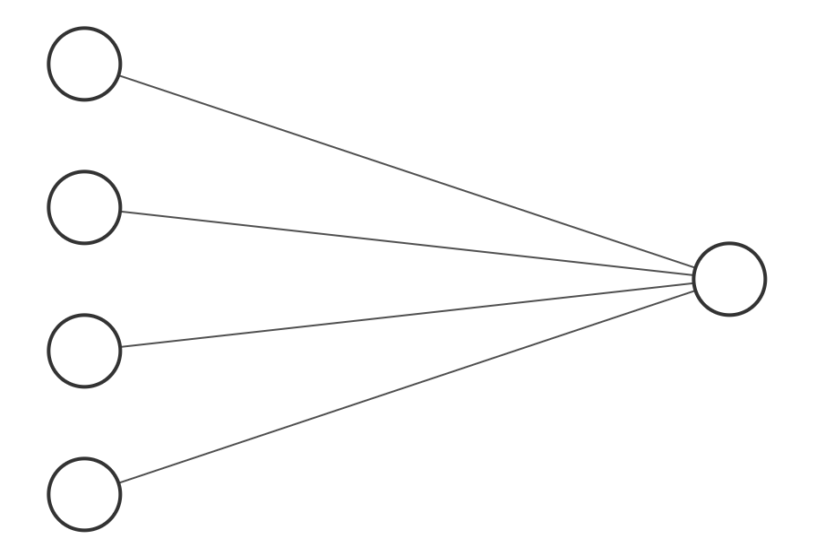

We feed this image forward in the network, and get a probability of 0.2 – yikes!

We can actually write out how this 0.2 was calculated

$$0.2 = \sigma\left (w_{1} a_{1}^{(2)} + w_{2} a_{2}^{(2)} + w_{3} a_{3}^{(2)} + w_{4} a_{4}^{(2)} + b \right)$$

where $a_i$ is the $i$th transformed feature from the second to last layer, denoted by the $^{(2)}$

So we want this probability to *go up*, because we want the neural network to classify this image as a 7. The loss is:

$$-1 \times \log(0.2) = 1.609$$

What can we control?

- Increase $b$
- Change $w_1, w_2, w_3, w_4$
- Change $a_1^{(2)}, a_2^{(2)}, a_3^{(2)}, a_4^{(2)}$

Increasing $b^{(3)}$ and changing $w_1^{(3)}, \dots, w_4^{(3)}$ is a straightforward use of calculating the gradient

$$\frac{\partial L}{\partial w_1^{(3)}} = \frac{\partial L}{\partial z} \frac{\partial z}{\partial w_1}$$

where $z = w_{1} a_{1}^{(2)} + w_{2} a_{2}^{(2)} + w_{3} a_{3}^{(2)} + w_{4} a_{4}^{(2)} + b$

For those that have taken calculus, this is the *chain rule*

We also know that the feature $a_1^{(2)}$ is also transformed from a previous set of features.

$$a_1^{(2)} = \text{ReLU}(w_{11} a_1^{(1)} + w_{12}a_2^{(1)} + w_{13}a_3^{(1)} + w_{14}a_4^{(1)} + b_1^{(2)})$$

We can calculate how the loss is affected using, again, the chain rule

$$\frac{\partial L}{\partial w_{11}} = \frac{\partial L}{\partial z} \frac{\partial z}{\partial a_1^{(2)}} \frac{\partial a_1^{(2)}}{\partial w_{11}}$$

This is why it is called *backpropagation*—you always start at your loss function, and calculate how much a weight or bias should get nudged going *backwards*

You can use backpropagation to calculate the gradient for all the weights and biases, $\nabla L$. We’ll then use gradient descent to update the parameters accordingly.

In theory, you would calculate gradients for all weights and biases using every training example, and then averaging the gradients across all training examples.

$\to$ So if one example tells $w_{11}$ to increase by 0.01, and another tells $w_{11}$ to decrease by 0.005, $w_{11}$ will increase by 0.0025

In practice, this is not computationally feasible, so we use *minibatches* (controlled using the batch size)

## Stochastic Gradient Descent

- Because we’re not using the gradient from the entire dataset, but instead, using gradients of a randomly selected subset of data, this is known as *stochastic* gradient descent (SGD)
- Adam is an SGD method that improves upon vanilla SGD

Gradient descent also requires multiple iterations, so it is typical to go through your entire training data set several times (determined by the number of *epochs*)

So you can go through the lab’s code from last class, and most of the components should make sense now!

- Learning rate
- Epochs
- Batch size
- Cross-Entropy Loss
- Adam optimizer